# STA207-The Effect of Region and Vaccine on the COVID-19 Death Rate

Yudong Wang

2/28/2022

# Abstract

In this project, I did a research on effects of region and vaccine, both individual and interactive, on the recent COVID pandemic’s death rate. By fitting a two way ANOVA model to the dataset and used F-test to make sure the explanatory variables are significant, I found out that region and vaccine will affect the mortality rate of COVID-19, and the interaction effect is also present in the model. This result shows that different regions will have distinctive death rate due some possible differences, such as tradition, policy, and even genes. It’s also a proof of vaccine’s effectiveness toward the COVID-19, so anti-vaccine movement is kind of a non-sense behavior. From this research, I urge the countries all over the world should take this pandemic more seriously, invest more money and efforts in decreasing possible virus outbreak, and promote the vaccination in their territories. These actions can help the whole world in today’s globalization situation.

# Introduction

Since late 2019, the new virus called COVID-19 casted great shadow over the world. Its high transmission rate and deadly effects caused big troubles worldwide and so many people had passed away because of it. However, from the reports we know the COVID-19’s deadliness is different in many situations, and I’m personaly more interested in the effect of different region and vaccination. The vaccination is easy to explain. There are many people doubting the effect of COVID vaccine and some are even against using it. Thus, I would like to know if the vaccine really has effect on the mortality rate or it’s just a lie told by the government. The region, on the other hand, involves reasons from multiple aspects. For example, both virus policy and climate may affect COVID’s effectiveness, so countries surely should be an important influencer to the COVID. However, using all countries can be tedious and hard to interpret, so I would like to compress them into regions, which can maintain the differences and be easier to interpret at the same time. To evaluate region and vaccine’s effect on COVID, I would like to fit a model of the mortality rate against the region and vaccination. The result of this model can help the readers get a more scientific attitude toward this pandemic. Hopefully, my research can be part of the helping hands that pushed the humanity out of the dire situation caused by the COVID-19.

### Background

But before get right into the model part, I would like to first share some backgrounds of this COVID-19 pandemic. Although COVID-19 started in late 2019 (it’s why it has 19 at the end), majority of the cases happened after 2020, and it’s also why the data I would use doesn’t contain many observations prior to 2020. Since today, there are over 450 million people infected by the virus and more than 6 million people passed away because of it worldwide (John Hopkins University, 2022).

In the introduction section, I mentioned that I will use region instead of countries because it’s easier to interpret the results. The regions are classified and named by the WHO (World Health Organization), and they are:

- AFRO: Africa Region
- AMRO: Americas Region
- EMRO: Eastern Mediterranean Region
- EURO: European Region
- SEARO: South-East Asian Region
- WPRO: Western Pacific Region

We can take a look at the cases of these regions with this map:

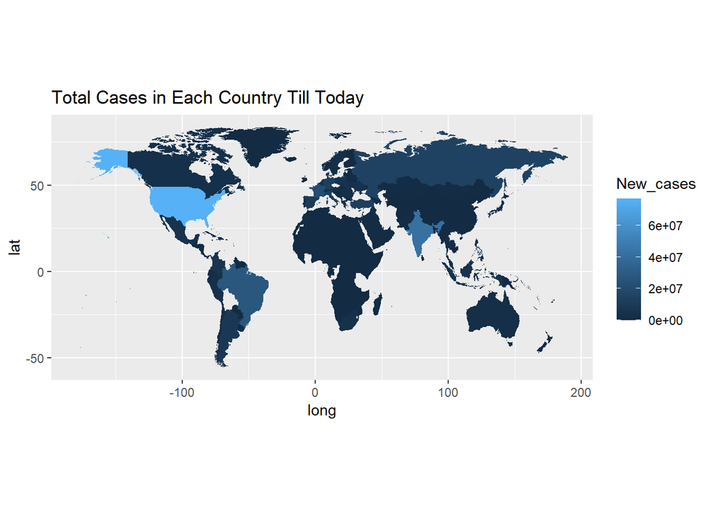

There are some countries missing in this map, but since most major countries are represented well in it, it’s still informative. From the map, we can see that the US, Brazil, India, Russia, and some European countries are the brightest, so they had the most COVID-19 cases during this pandemic. The death numbers, on the other hand, looks like this:

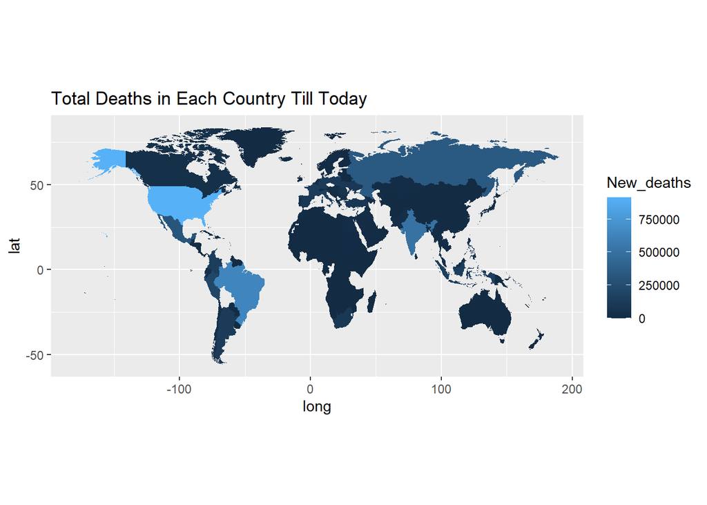

Overall, it’s pretty similar to the total cases map. So we can probably say that AMRO, EMRO, and EURO may be the regions with the highest death rates worldwide. It’s kind of counter-intuitive because we tend to believe that these regions have better technologies and should perform better during this pandemic, but they actually have more cases than other regions. Also, the AFRO has surprisingly low number of cases and deaths, and this may be caused by the high temperature limited COVID-19’s transmission ability (Heibati, 2021).

# Descriptive analysis

In this research, two datasets are being used. They are both provided by the WHO on its official website, so they are both very trustworthy. The first dataset is called “WHO-COVID-19-global-data.csv” (will be called “Covid dataset” in the later parts), and the second dataset is “vaccination-data.csv” (will be called “Vaccine dataset”). The Covid dataset contains observations between the beginning of COVID (01/03/2020) to the date this report is written (02/16/2022) from 237 countries worldwide, so there are 183912 observations in total. It also has 8 variables, including Date reported, Country name, Country code, etc. But I will only use Country, WHO Region, New cases, and New deaths because I’m more interested in these topics. The Vaccine dataset contains 228 observations of 14 variables, but since we are only interested in the date when each country gets their first vaccine, I would only use Country and First vaccine date.

- Country: name of the country
- WHO_region: region of the country designated by WHO
- First_vaccine_date: first date of using vaccine in that country
- Date_reported: date of new cases and new deaths
- New_cases: new cases per day
- New_deaths: new deaths per day
- startvac: whether the country is using vaccine at that day
- deathrate: death rate of that day
- avg_deathrate: 14-days average death rate

Now let’s take a look at some plots. The first plot I would like to show is the spaghetti plot of average 14-days death rate vs. date in each region.

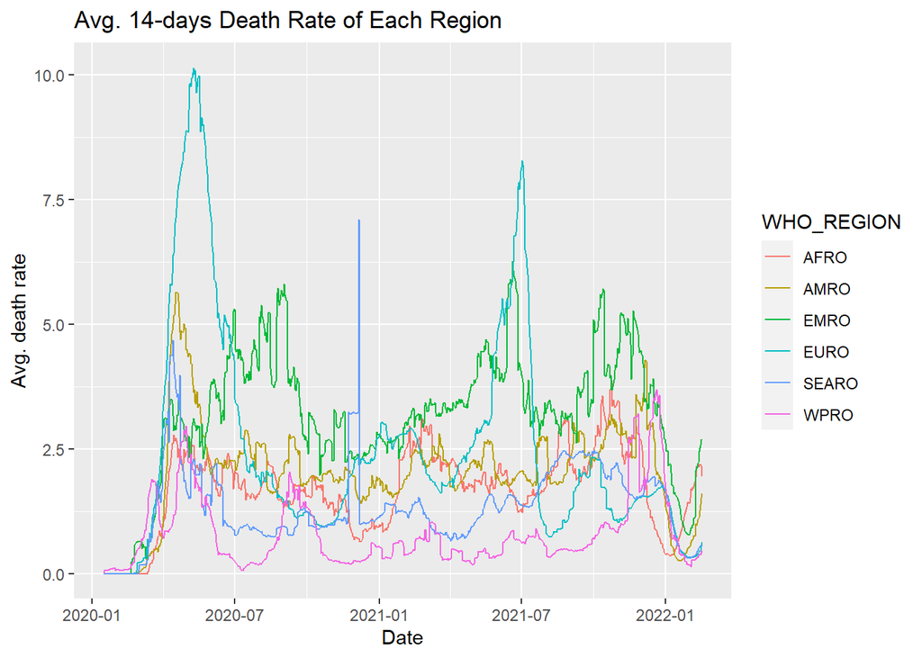

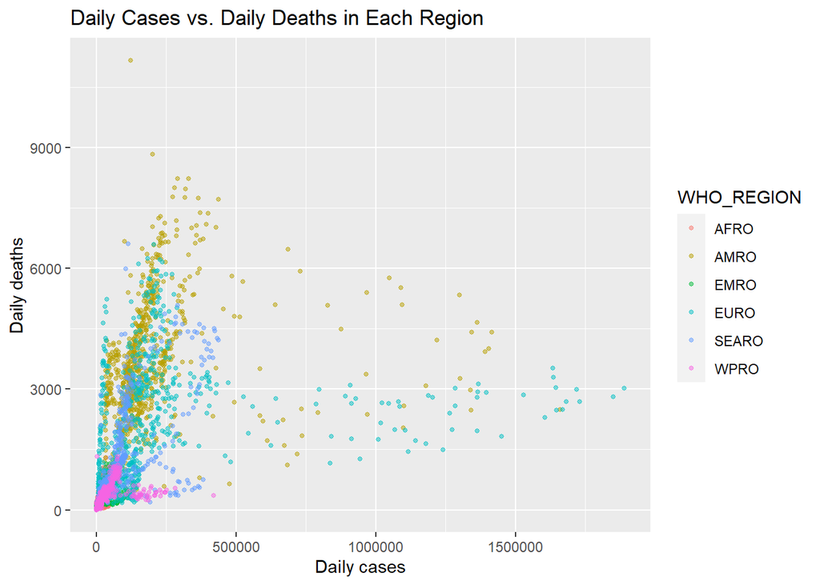

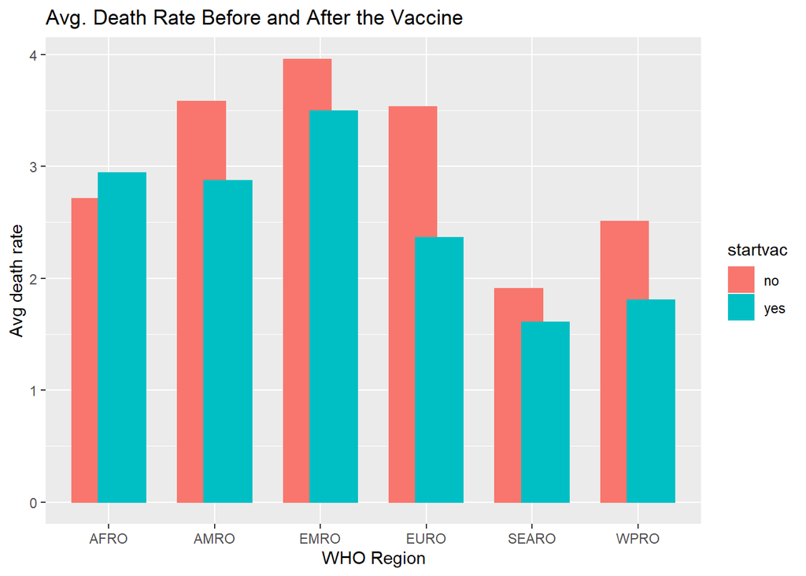

From the bar plot, we can see that most regions have their average death rate decreased after the introduction of vaccine except AFRO region. This fits our expectation of vaccine’s effect on controlling the death rate, but AFRO’s strange behavior may need more research. The next part would be two factor effect plots (with $\alpha = 0.01$) showing the numerical values of each region and vaccine’s effect on death rate.

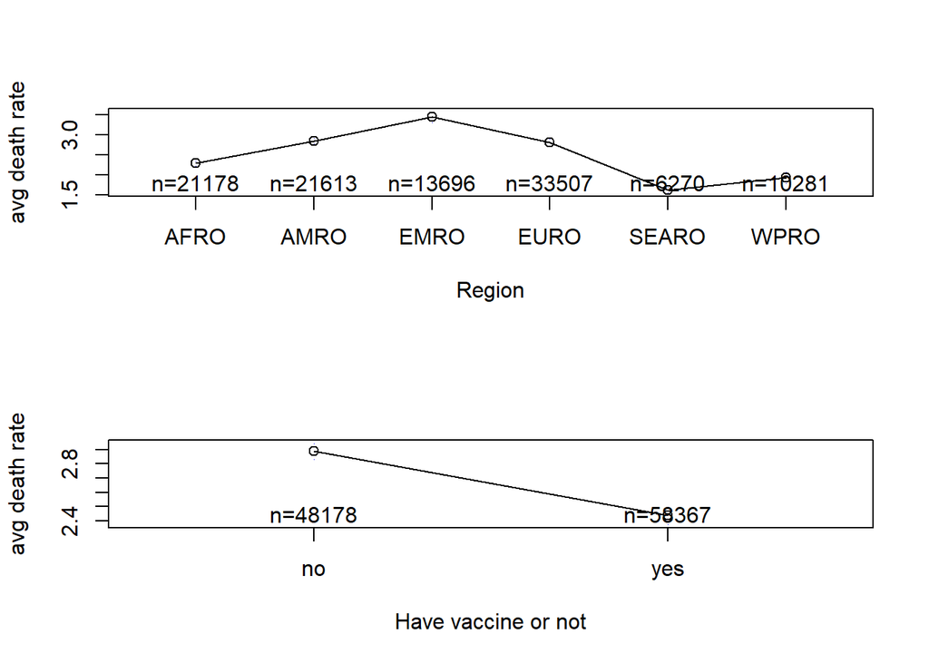

Overall, we can see that the numerical values of death rate also supports my interpretation on the previous plots. AMRO, EMRO, and EURO are the three regions with the highest death rate, and vaccine is helpful in decreasing the death rate. However, before making conclusions right now, their true effects still need to be tested by the model in the later part of this project.

# Inferential analysis

In this project, my initial guess of the appropriate model would be a two way ANOVA model with interaction terms. I choose this model in particular because there are multiple explanatory variables I’m interested in, so one way ANOVA model would be insufficient for sure. Also, I’m more interested in whether there’s difference between each region’s death rate before/after the COVID-19 vaccine, so no multiple regression is needed here.

The first model is simple: $Avg \space Death \space Rate_{ijk} = \mu + Region_i + Vaccine_j + (Region*Vaccine)_{ij}+\epsilon_{ijk}$. However, when checking its assumptions, I found it performed badly in terms of normality, so I also ran a boxcox plot to see what transformation might be useful in solving this problem.

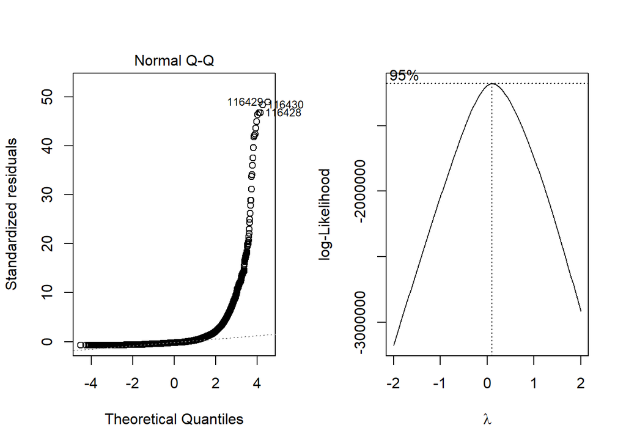

With the help from boxcox plot, I decided to use log transformation on the response variable. However, the performance of the model is still not great. Thus, I tried to add some constants on top of the original response variable, and after few tries, I found the best performing model, and the The final model is:

$$log(Y_{ijk}+\frac{1}{4}) = \mu + R_i + V_j + (RV)_{ij}+\epsilon_{ijk}$$
where

- $Y_{ijk}$ = the average 14-days death rate of each country
- $\mu$ = the overall mean of average 14-days death rate
- $R_i$ = factor effect of each region
- $V_j$ = factor effect of having vaccine or not
- $(RV)_{ij}$ = the interaction effect
- $\epsilon_{ijk}$ = the residuals

and

- $\sum R_i = \sum V_j = 0$
- $\sum^r_{i = 1} (RV)_{ij} = \sum^v_{j = 1} (RV)_{ij} = 0$
- $\epsilon_{ijk}$ are iid $N(0, \sigma^2)$

These are the summary of the model I fit:

```
##                         Df Sum Sq Mean Sq F value Pr(>F)
## WHO_REGION               5  25227    5045  3739.9 <2e-16 ***
## startvac                 1   2938    2938  2177.7 <2e-16 ***
## WHO_REGION:startvac      5   1033     207   153.1 <2e-16 ***
## Residuals           157020 211828       1
## ---
## Signif. codes:  0 '***' 0.001 '**' 0.01 '*' 0.05 '.' 0.1 ' ' 1
```

Next, I would like to use hypothesis tests to see if the explanatory variables in the model can be removed. I used the F-test to achieve this goal. By setting the the null hypothesis as $H_0: all \space R_i = 0$ and $H_1: not \space all \space R_i = 0$, I can begin the test on Region’s significance

```
##               f_score crit_value
## Region      3739.8919   3.350067
## Vaccine     2177.6833   7.879661
## Interaction  153.0961   3.350067
```

Although I’m not very interested in the real difference between each region and vaccination, it’s still a wise choice to take a quick peek at them. Thus, I also did a Tukey test, and the results are:

```
##                  diff        lwr        upr        p adj
## AMRO-AFRO   0.3431760  0.2434025  0.4429495 6.228351e-14
## EMRO-AFRO   1.4568312  1.3323070  1.5813555 0.000000e+00
## EURO-AFRO   0.8364180  0.7397947  0.9330414 0.000000e+00
## SEARO-AFRO -0.3320727 -0.4970313 -0.1671140 1.444632e-07
## WPRO-AFRO  -0.8907072 -0.9967789 -0.7846355 0.000000e+00
## EMRO-AMRO   1.1136552  0.9882556  1.2390548 0.000000e+00
## EURO-AMRO   0.4932420  0.3954931  0.5909910 0.000000e+00
## SEARO-AMRO -0.6752487 -0.8408691 -0.5096282 0.000000e+00
## WPRO-AMRO  -1.2338832 -1.3409812 -1.1267852 0.000000e+00
## EURO-EMRO  -0.6204132 -0.7433212 -0.4975051 0.000000e+00
## SEARO-EMRO -1.7889039 -1.9705124 -1.6072953 0.000000e+00
## WPRO-EMRO  -2.3475384 -2.4780049 -2.2170719 0.000000e+00
## SEARO-EURO -1.1684907 -1.3322327 -1.0047487 0.000000e+00
## WPRO-EURO  -1.7271252 -1.8312948 -1.6229556 0.000000e+00
## WPRO-SEARO -0.5586345 -0.7281237 -0.3891454 5.662137e-14
```

```
##             diff        lwr       upr        p adj
## yes-no 0.1387402 0.09338109 0.1840993 2.035462e-09
```

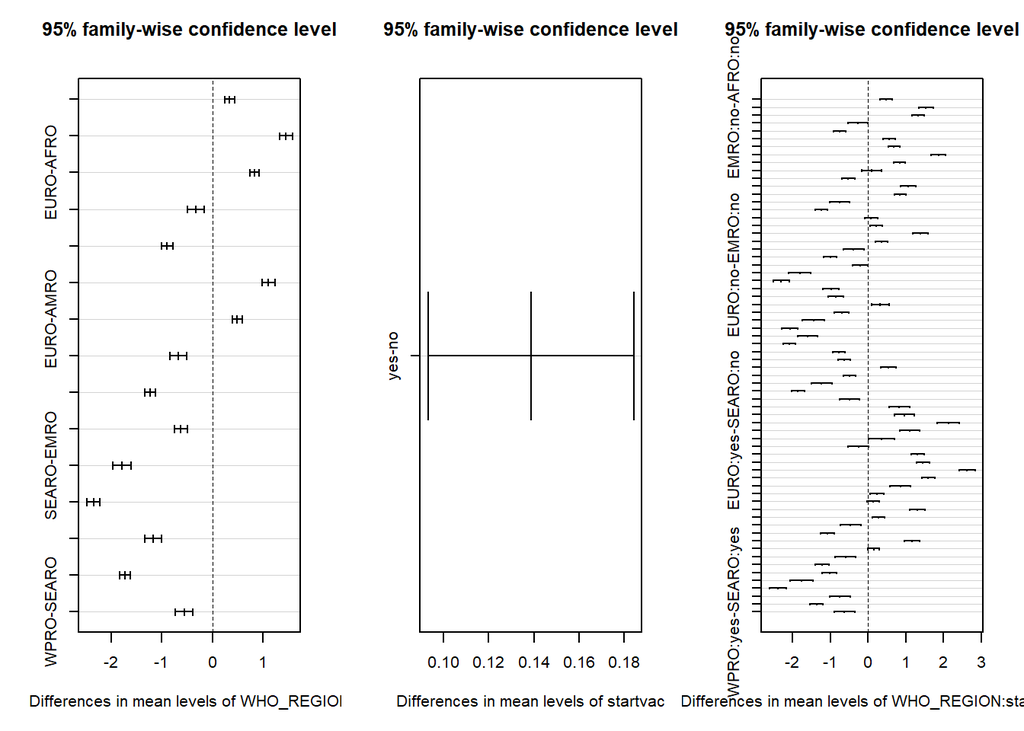

# Sensitivity analysis

The last step is to check whether my model holds the model assumptions. One of the best way is to check the residual plots and QQ-plot.

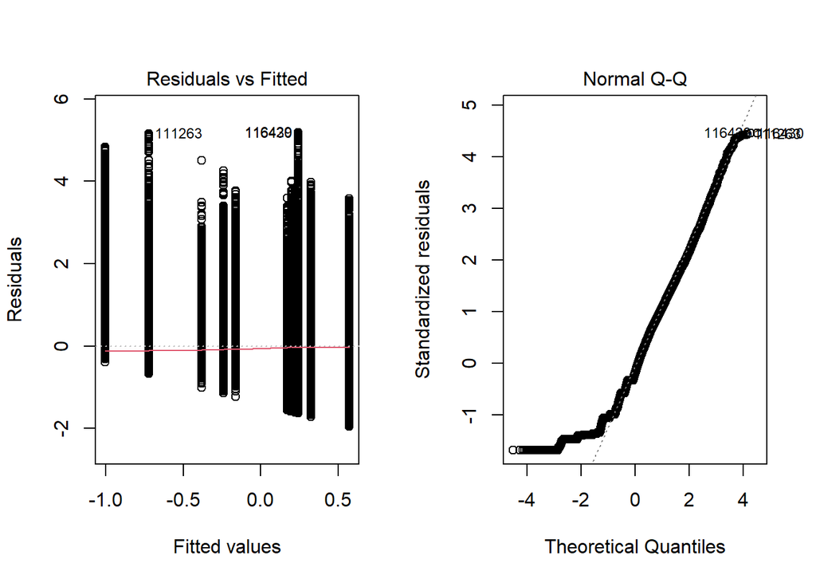

```
## Levene's Test for Homogeneity of Variance (center = median)
##           Df F value    Pr(>F)
## group     11  1372.4 < 2.2e-16 ***
##       157020
## ---
## Signif. codes:  0 '***' 0.001 '**' 0.01 '*' 0.05 '.' 0.1 ' ' 1
```

But by looking at the histogram of the response variable, we can see what caused this problem:

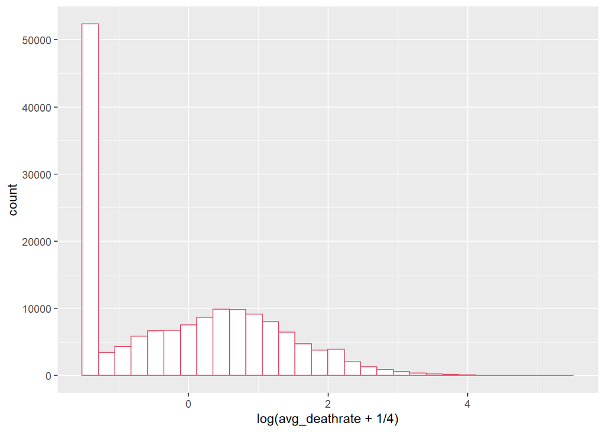

From the histogram above, it’s easy to find out that there are a lot of values stacking at the leftmost section. It’s because there are many observations of average 14-days death rate are equal to 0. This makes the variable not normal, and if we ignore this part, the rest observations are pretty close to the normal distribution like these

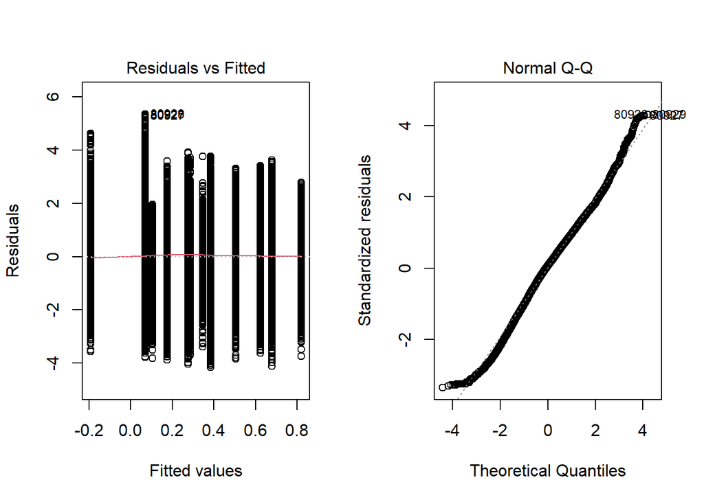

The residual plots also looks good

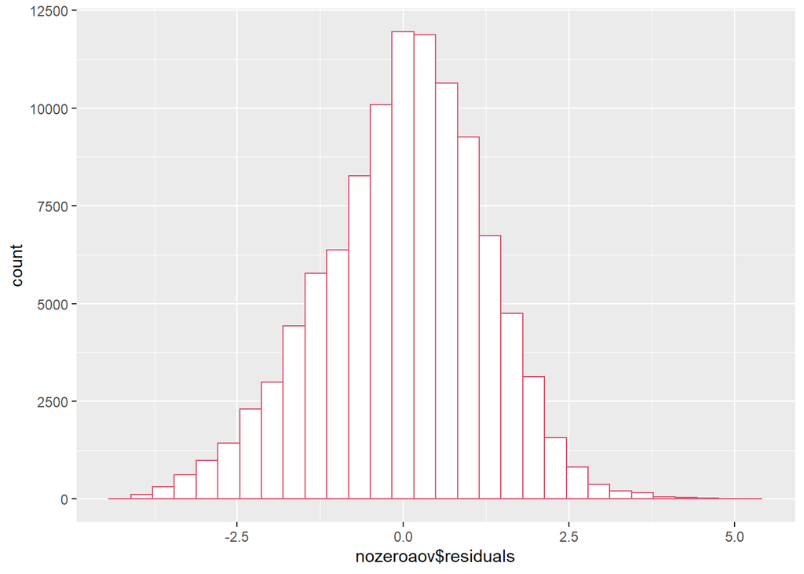

However, since the 0 average 14-days death rate has its meaning, we can’t simply remove these observations, so I will stick with my final model even though it violated some assumptions.

# Conclusion

But still, I would like to urge people worldwide to get vaccinated because it’s proved to help the humanity to fight against this deadly pandemic, and I wish regions with higher technology and utilize their advantages better, so more people may survive. At the end, I hope my project can help more people to realize the effect of vaccine and region on the COVID-19’s mortality rate, so we can have a better world in the future.

# Appendix

### GitHub link

https://github.com/7qiwx/207project/tree/main/Yudong%20Wang

### Reference

Heibati, Behzad, et al. “Weather Conditions and COVID-19 Incidence in a Cold Climate: A Time-Series Study in Finland.” Frontiers, Frontiers in Public Health, 25 May 2021, https://www.frontiersin.org/articles/10.3389/fpubh.2020.605128/full.

Hopkins, John. “Coronavirus Resource Center.” Johns Hopkins Coronavirus Resource Center, John Hopkins University, https://coronavirus.jhu.edu/.

### Codes

```r
knitr::opts_chunk$set(echo = TRUE)
options(warn = -1)
library(dplyr)
library(ggplot2)
library(MASS)
library(gplots)
library(car)
library(maps)
# read the data
main = read.csv("WHO-COVID-19-global-data.csv")
vac = read.csv("vaccination-data.csv")
colnames(main)[1] = "Date_reported"

# merge the data sets and do some manipulation
mydata = vac %>%
  filter(FIRST_VACCINE_DATE != "") %>%
  right_join(main, by = c("COUNTRY" = "Country")) %>%
  dplyr::select(COUNTRY,WHO_REGION,FIRST_VACCINE_DATE,Date_reported,New_cases,New_deaths) %>%
  mutate(FIRST_VACCINE_DATE = as.Date(FIRST_VACCINE_DATE)) %>%
  mutate(Date_reported = as.Date(Date_reported)) %>%
  na.omit() %>%
  mutate(startvac = ifelse(FIRST_VACCINE_DATE>Date_reported, "no","yes")) %>%
  mutate(deathrate = ifelse(New_cases == 0, 0, New_deaths/New_cases*100))

# get the 7 day avg death rate
mydata = mydata %>%
  group_by(COUNTRY) %>%
  mutate(avg_deathrate = stats::filter(deathrate, filter = rep(1/14,14), side = 1)) %>%
  filter(avg_deathrate >= 0) %>%
  na.omit()

# plot the map, just following the steps in professor's sample
world <- map_data("world");
worldplot <- ggplot() +
  geom_polygon(data = world, aes(x=long, y = lat, group = group))
# get the total cases in each region
covid = main %>%
  group_by(Country) %>%
  summarise(New_cases = sum(New_cases), New_deaths = sum(New_deaths)) %>%
  mutate(region = Country) %>%
  mutate(region = replace(region, region == "United States of America", "USA")) %>%
  mutate(region = replace(region, region == "Russian Federation", "Russia"))
# combine the dataset
covid.world<- inner_join(world, covid, by = "region")
# plot the map
fig.map  <- ggplot() +
  geom_polygon(data = covid.world, aes(x=long, y = lat, group = group, fill=New_cases)) +
  coord_fixed(1.3) + ggtitle("Total Cases in Each Country Till Today")
fig.map
fig.map  <- ggplot() +
  geom_polygon(data = covid.world, aes(x=long, y = lat, group = group, fill=New_deaths)) +
  coord_fixed(1.3) + ggtitle("Total Deaths in Each Country Till Today")
fig.map
# get the dataset with avg region death rate
region_death = mydata %>%
  group_by(Date_reported, WHO_REGION) %>%
  mutate(region_death = mean(avg_deathrate))


# plot avg death rate in each region
ggplot(region_death, aes(x = as.Date(Date_reported), y = region_death)) +
  geom_line(aes(color = WHO_REGION)) + ggtitle("Avg. 14-days Death Rate of Each Region") + xlab("Date") + ylab("Avg. death rate")
mydata %>%
  group_by(WHO_REGION, Date_reported) %>%
  summarise(New_cases = sum(New_cases), New_deaths = sum(New_deaths)) %>%
  ggplot(aes(x = New_cases, y = New_deaths, col = WHO_REGION)) + geom_point(alpha = 0.5, size = 1) + ggtitle("Daily Cases vs. Daily Deaths in Each Region") + xlab("Daily cases") + ylab("Daily deaths")
# get the average deathrate of each region
region_deathrate = mydata %>%
  filter(New_cases > 0) %>%
  group_by(WHO_REGION, startvac) %>%
  summarise(avg_deathrate = mean(deathrate))
# plot the histogram
ggplot(region_deathrate, aes(x = WHO_REGION, y = avg_deathrate)) + geom_bar(aes(color = startvac, fill = startvac), stat = 'identity', position = position_dodge(width = 0.5)) + ggtitle("Avg. Death Rate Before and After the Vaccine") + xlab("WHO Region") + ylab("Avg death rate")
options(warn = -1)
par(mfrow = c(2,1))
region_death = region_death %>%
  filter(New_cases > 0)
plotmeans(region_death$avg_deathrate~region_death$WHO_REGION, p = 0.99, xlab = "Region", ylab = "avg death rate")
plotmeans(region_death$avg_deathrate~region_death$startvac, p = 0.99, xlab = "Have vaccine or not", ylab = "avg death rate")
# 1st ANOVA model
myaov = aov((avg_deathrate+0.00001)~WHO_REGION*startvac, data = mydata)
par(mfrow = c(1,2))
# check normality
plot(myaov, which = c(2))
# find transformation
boxcox(myaov)
# 2nd ANOVA model with log transformation
logaov = aov((log(avg_deathrate+1/4))~WHO_REGION*startvac, data = mydata)
summary(logaov)
# get the f score and crit value table
f_score = c(anova(logaov)$`F value`[1:3])
crit_value = c(qf(1-0.01/2, 5, 157020), qf(1-0.01/2, 1,157020), qf(1-0.01/2, 5, 157020))
ftable = data.frame(f_score, crit_value)
row.names(ftable) = c("Region", "Vaccine","Interaction")
ftable
# run the Tukey test
mytukey = TukeyHSD(myaov)
mytukey$WHO_REGION
mytukey$startvac
par(mfrow = c(1,3))
plot(mytukey)
# check normality
par(mfrow = c(1,2))
plot(logaov, which = c(1,2))

# levene test for equal variance
leveneTest((log(avg_deathrate+1/4))~interaction(WHO_REGION, startvac), data = mydata)
# get the histogram
ggplot(mydata, aes(x = log(avg_deathrate + 1/4))) +
geom_histogram(colour = 2, fill ="white")
# get dataset without 0
nozero = mydata %>%
  filter(avg_deathrate > 0)
nozeroaov = aov((log(avg_deathrate+0.02))~WHO_REGION*startvac, data = nozero)
# plot the residual and qqplot
par(mfrow = c(1,2))
plot(nozeroaov, which = c(1,2))
# histogram of residual
ggplot(nozero, aes(x = nozeroaov$residuals)) +
geom_histogram(colour = 2, fill ="white")
```